# AMR & SSI in ECSA: Synthesis (Enhanced Visualizations)

Marion Korir et al.

```r
# Set global chunk options
knitr::opts_chunk$set(echo = FALSE, message = FALSE, warning = FALSE)

# --- Package Management ---
# This chunk checks for missing packages and installs them if necessary.
required_packages <- c(
  "tidyverse", "janitor", "gtsummary", "meta", "stringr",
  "countrycode", "mapproj", "viridis", "patchwork", "rprojroot", "knitr", "scales"
)
missing_packages <- required_packages[!(required_packages %in% installed.packages()[,"Package"])]
if(length(missing_packages) > 0) {
  install.packages(missing_packages)
}

# Load required packages
suppressPackageStartupMessages({
  library(tidyverse)
  library(janitor)
  library(gtsummary)
  library(meta)
  library(stringr)
  library(countrycode)
  library(mapproj)
  library(viridis) # For better color scales
  library(patchwork) # For combining plots
})

# Set a consistent, clean theme for all ggplot visualizations
theme_set(theme_light() + theme(
  plot.title = element_text(face = "bold", size = 14),
  plot.subtitle = element_text(size = 11, color = "gray30"),
  plot.caption = element_text(color = "gray50"),
  strip.text = element_text(face = "bold")
))

# --- Data Loading and Cleaning ---
# Find the project root to create a robust file path
root <- rprojroot::find_root(rprojroot::has_file("amr-ssi-ecsa.Rproj"))
file <- file.path(root, params$data_file)
if (!file.exists(file)) {
  stop("Data file not found: ", file)
}

# Read and clean the data
df <- readr::read_csv(file, show_col_types = FALSE) %>%
  clean_names()

# Minimal helper functions
`%||%` <- function(a, b) if (!is.null(a) && length(a) > 0 && !all(is.na(a))) a else b
num <- function(x) readr::parse_number(as.character(x))
yn <- function(x) case_when(
  is.na(x) ~ NA_character_,
  str_to_lower(x) %in% c("yes","y","true") ~ "Yes",
  str_to_lower(x) %in% c("no","n","false") ~ "No",
  TRUE ~ str_to_sentence(x)
)

# Derive a study_id if it doesn't exist
if (!"study_id" %in% names(df)) {
  df <- df %>% mutate(
    first_author = str_remove(str_to_sentence(author %||% ""), ",.*$"),
    study_id = paste0(first_author, "_", year_of_publication %||% "")
  )
}

# Process country data for mapping and analysis
countries_long <- df %>%
  mutate(country_list = str_split(country_list %||% "", ";\\s*")) %>%
  unnest(country_list) %>%
  filter(!is.na(country_list) & country_list != "") %>%
  mutate(region = countrycode(country_list, "country.name", "region"))

country_counts <- countries_long %>%
  count(country_list, name = "n_studies") %>%
  rename(country = country_list)
```

## 1 Overview and Dataset

This section provides a high-level summary of the included studies, their geographic distribution, and publication timeline.

Sample of included studies

| study_id | author | year_of_publication | title_of_paper | study_design_mece |
| --- | --- | --- | --- | --- |
| Akoachere jane-francis tatah kihla_2014 | Akoachere Jane-Francis Tatah Kihla, Palle John Ngunde, Mbianda Soupsop Evelyn, Nkwelang Gerard, Roland Ndip Ndip | 2014 | Risk factors for wound infection in health care facilities in Buea, Cameroon: aerobic bacterial pathogens and antibiogram of isolates | Cross-sectional |
| Kachipedzu amos tumizani_2024 | Kachipedzu Amos Tumizani, David King Kulapani, Samuel James Meja, Janelisa Musaya | 2024 | Surgical site infection and antimicrobial use following caesarean section at QECH in Blantyre, Malawi: a prospective cohort study | Cohort |
| Hope derick_2019 | Hope Derick, Lucas Ampaire, Caesar Oyet, Enoch Muwanguzi, Hillary Twizerimana, Richard Onyuthi Apecu | 2019 | Antimicrobial resistance in pathogenic aerobic bacteria causing surgical site infections in Mbarara regional referral hospital, Southwestern Uganda | Cross-sectional |
| Odoko desta_2024 | Odoko Desta, Abera Kumalo, Getachew Alemu, Tigistu Demisse, Teshale Mulugeta, Muluneh Temesgen | 2024 | Extended-spectrum ß-lactamase and carbapenemase producing Enterobacteriaceae among patients suspected with surgical site infection at Hospitals in Southern Ethiopia | Cross-sectional |
| Dinda victor_2013 | Dinda Victor, Gunturu Revathi, Kariuki Sam, Hakeem Abdi, Raja Asad, Kimang’a Andrew | 2013 | Pattern of Pathogens and their Sensitivity Isolated from Surgical Site Infections at the Aga Khan University Hospital, Nairobi, Kenya | Cohort |
| Gentilotti elisa_2020 | Gentilotti Elisa, Pasquale De Nardo, Boniface Nguhuni, Alessandro Piscini, Caroline Damian, Francesco Vairo, Zainab Chaula, Paola Mencarini, Peter Torokaa, Alimuddin Zumla, Emanuele Nicastri, Giuseppe… | 2020 | Implementing a combined infection prevention and control with antimicrobial stewardship joint program to prevent caesarean section surgical site infections and antimicrobial resistance: a Tanzanian te… | Before-after |
| Gemedo misha_2021 | Gemedo Misha, Legese Chelkeba, Tsegaye Melaku | 2021 | Bacterial profile and antimicrobial susceptibility patterns of isolates among patients diagnosed with surgical site infection at a tertiary teaching hospital in Ethiopia: a prospective cohort study | Cohort |
| Haitham hamudu_2025 | Haitham Hamudu, Helmut Nyawale, Vitus Silago, Mariam M. Mirambo, Phillipo L. Chalya, Stephen E. Mshana | 2025 | Incidence, bacteriological profile and predictors of surgical site infections following limb amputation at Bugando medical centre and Sekou toure referral regional hospital, Mwanza, Tanzania | Cohort |
| Ojulong julius_2009 | Ojulong Julius, T.P. Mwambu, M. Joloba, F. Bwanga, D.H. Kaddu-Mulindwa | 2009 | Relative prevalence of methicilline resistant Staphylococcus aureus and its susceptibility pattern in Mulago Hospital, Kampala, Uganda | Cross-sectional |
| Iyamba jean-marie liesse_2014 | Iyamba Jean-Marie Liesse, José Mulwahali Wambale, Cyprien Mbundu Lukukula, Ntondo za Balega Takaisi-Kikuni | 2014 | High prevalence of methicillin resistant staphylococci strains isolated from surgical site infections in Kinshasa | Cross-sectional |

|  | Value |
| --- | --- |
| Number.of.unique.studies | 40 |
| Publication.year.range | 2009 - 2025 |
| Number.of.unique.countries | 16 |

### 1.1 Geographic Distribution of Studies

This map shows the number of included studies per country, helping to quickly identify geographic clusters and gaps in the evidence base.

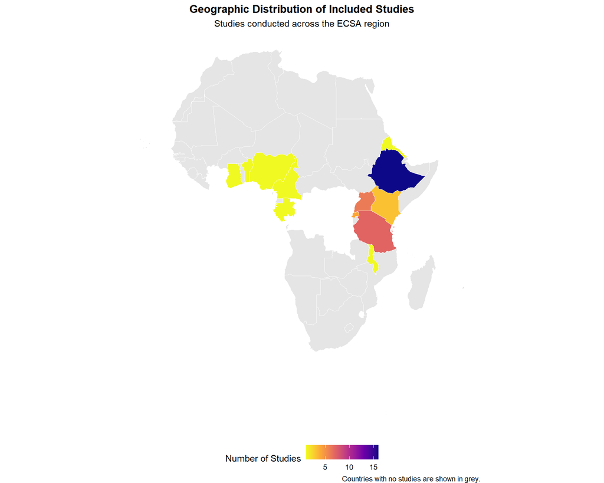

### 1.2 Timeline of Study Publication

This plot shows the number of studies published each year, illustrating trends in research activity over time.

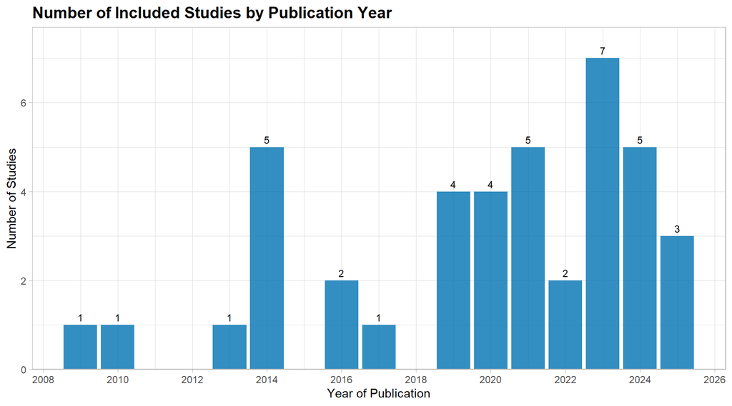

## 2 Study Characteristics

### 2.1 Table 1: Summary of Study Characteristics

| **Characteristic** | **N = 41**<sup>1</sup> |
| --- | --- |
| Study Design |  |
| Before-after | 1 (2.4%) |
| Cohort | 11 (27%) |
| Cross-sectional | 26 (63%) |
| RCT | 2 (4.9%) |
| Surveillance | 1 (2.4%) |
| Facility Level |  |
| district | 1 (2.4%) |
| private | 1 (2.4%) |
| tertiary/referral/teaching | 34 (83%) |
| unspecified | 5 (12%) |
| Surgical Speciality |  |
| General Surgery | 4 (9.8%) |
| General Surgery; Head & Neck; OBGYN | 2 (4.9%) |
| General Surgery; Head & Neck; Orthopedics/Trauma; Urology | 1 (2.4%) |
| General Surgery; OBGYN | 4 (9.8%) |
| General Surgery; OBGYN; Orthopedics/Trauma | 8 (20%) |
| General Surgery; OBGYN; Orthopedics/Trauma; Pediatrics | 2 (4.9%) |
| General Surgery; OBGYN; Orthopedics/Trauma; Urology | 1 (2.4%) |
| General Surgery; Orthopedics/Trauma | 4 (9.8%) |
| General Surgery; Orthopedics/Trauma; Pediatrics | 4 (9.8%) |
| General Surgery; Orthopedics/Trauma; Urology | 1 (2.4%) |
| OBGYN | 7 (17%) |
| Orthopedics/Trauma | 1 (2.4%) |
| Other | 2 (4.9%) |
| SSI Denominator Type |  |
| Procedures | 24 (59%) |
| Ssi cohort only | 2 (4.9%) |
| Unclear | 15 (37%) |
| Used CDC Guidelines for Diagnosis | 22 (54%) |
| Lab Culture Confirmed | 20 (49%) |
| Follow-up at least 30 days | 5 (12%) |

<sup>1</sup> n (%)

### 2.2 Visual Summary of Study Characteristics

This plot provides a visual alternative to Table 1, making it easier to compare the distribution of key study features.

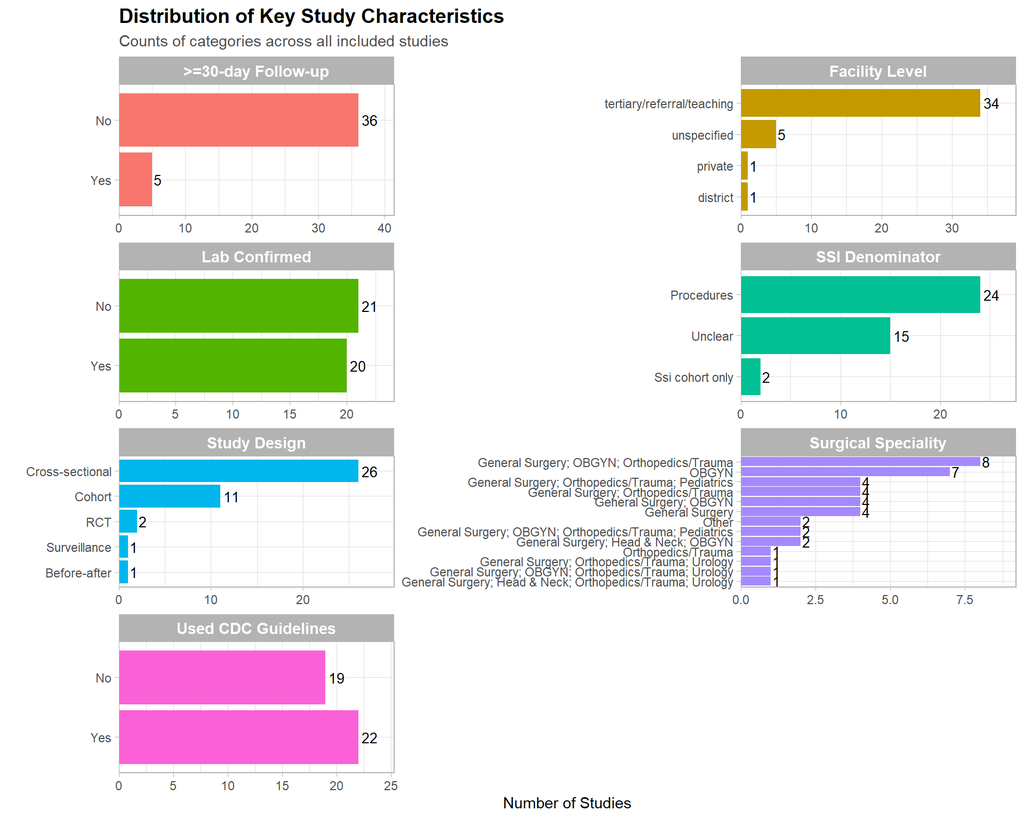

## 3 Meta-analysis: SSI Incidence

```
## Number of studies: k = 23
## Number of observations: o = 14798
## Number of events: e = 4331
##
##                      proportion           95%-CI
## Common effect model      0.2932 [0.2859; 0.3006]
## Random effects model     0.3684 [0.2032; 0.5511]
##
## Quantifying heterogeneity (with 95%-CIs):
##  tau^2 = 0.2009 [0.1199; 0.4045]; tau = 0.4483 [0.3462; 0.6360]
##  I^2 = 99.7% [99.7%; 99.8%]; H = 19.65 [18.74; 20.59]
##
## Test of heterogeneity:
##        Q d.f. p-value
##  8490.41   22       0
##
## Details of meta-analysis methods:
## - Inverse variance method
## - Restricted maximum-likelihood estimator for tau^2
## - Q-Profile method for confidence interval of tau^2 and tau
## - Calculation of I^2 based on Q
## - Freeman-Tukey double arcsine transformation
```

### 3.1 Forest Plot (ggplot2 Version)

This forest plot, created with `ggplot2`, offers a modern and clear visualization of the SSI incidence from each study and the pooled estimate. The diamond represents the overall random-effects model estimate.

[figure not shown]

### 3.2 Funnel Plot

A funnel plot can be used to assess potential publication bias.

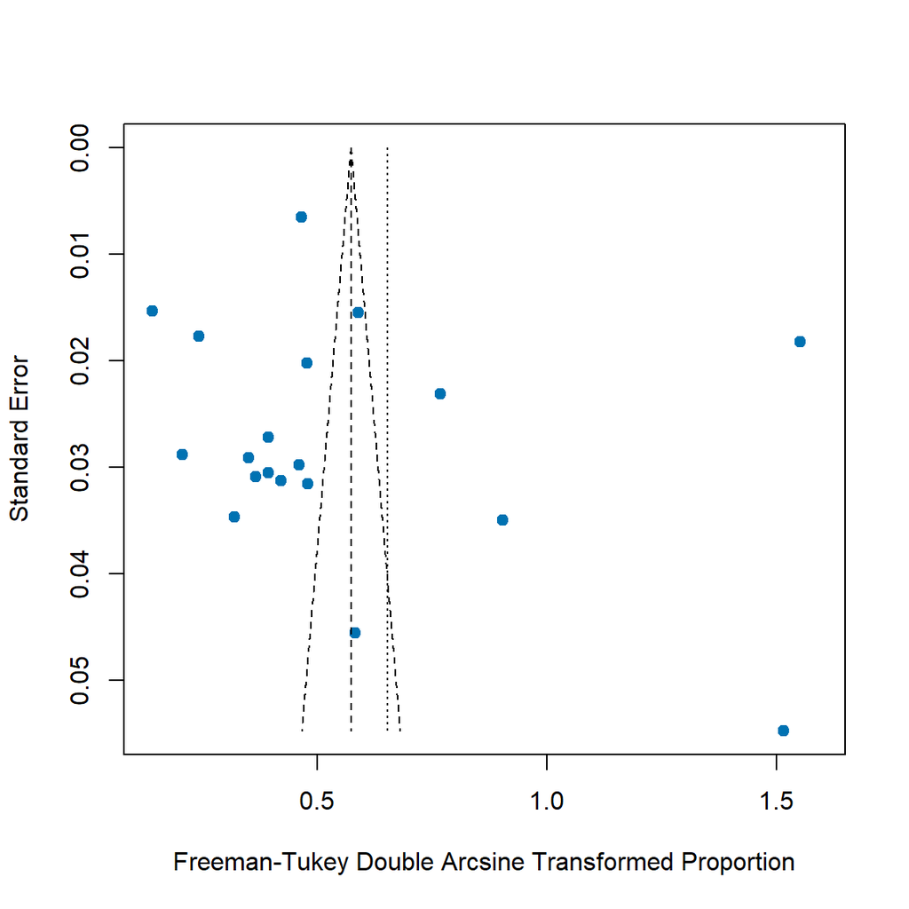

## 4 Pathogens and Resistance Patterns

### 4.1 Top Isolated Pathogens

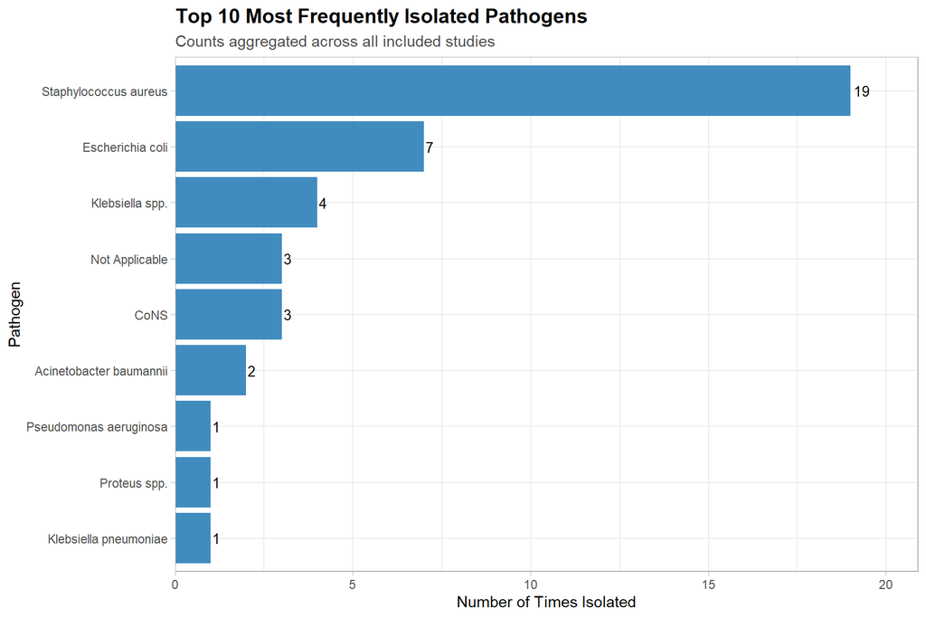

### 4.2 Antimicrobial Resistance Patterns (Heatmap Template)

**Note:** This visualization requires your data to be in a “tidy” or “long” format. A heatmap is an excellent way to show resistance rates of key pathogens to various antibiotics.

**Action Required:** You will need to prepare your AMR data. An ideal format would have columns like `study_id`, `pathogen_name`, `antibiotic_tested`, and `result` (e.g., ‘R’ for resistant, ‘S’ for susceptible).

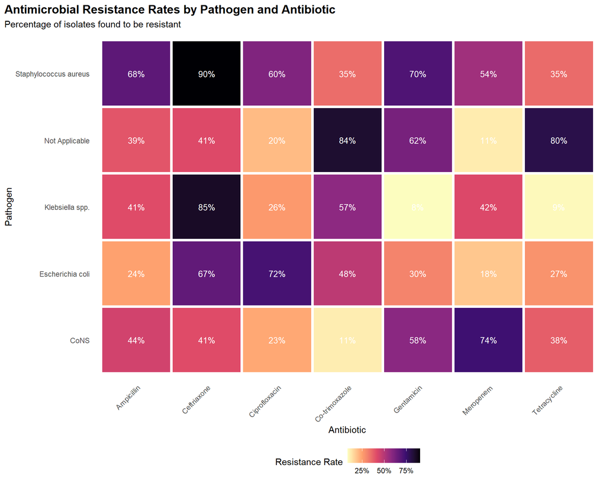

## 5 Thematic Synthesis

### 5.1 Frequency of Thematic Codes

This plot summarizes the frequency of themes identified across studies, categorized by their domain (e.g., Drivers of AMR, Interventions). This provides a quick overview of the key topics discussed in the literature.

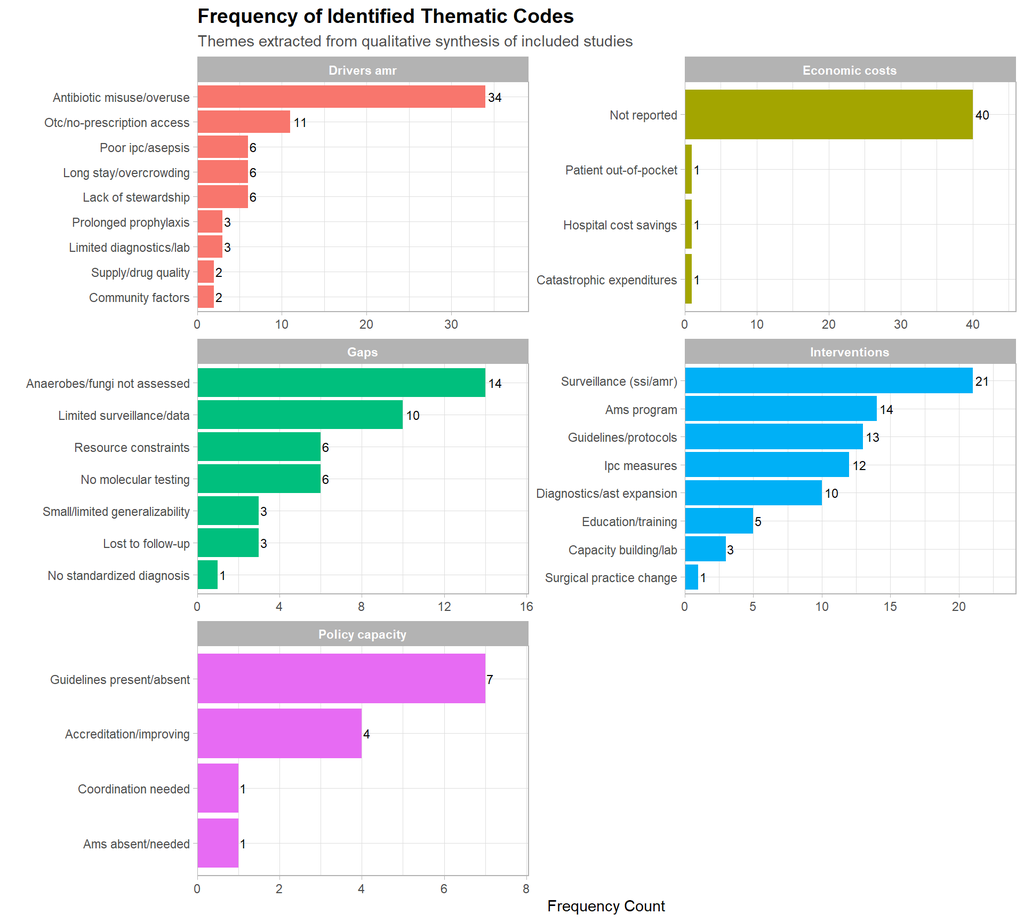

## 6 Narrative Synthesis

Limitations include data sparsity, reporting heterogeneity, and potential publication bias. Future work should standardize outcome definitions (CDC, 30-day follow-up), ensure routine culture/AST reporting, and quantify economic burden to inform regional stewardship and policy strategies.